# Project

Kai Lyu

April 10, 2018

## ARIMA+EGARCH Dynamic Predict Bitcoin Rate of Return

Download data from quandl

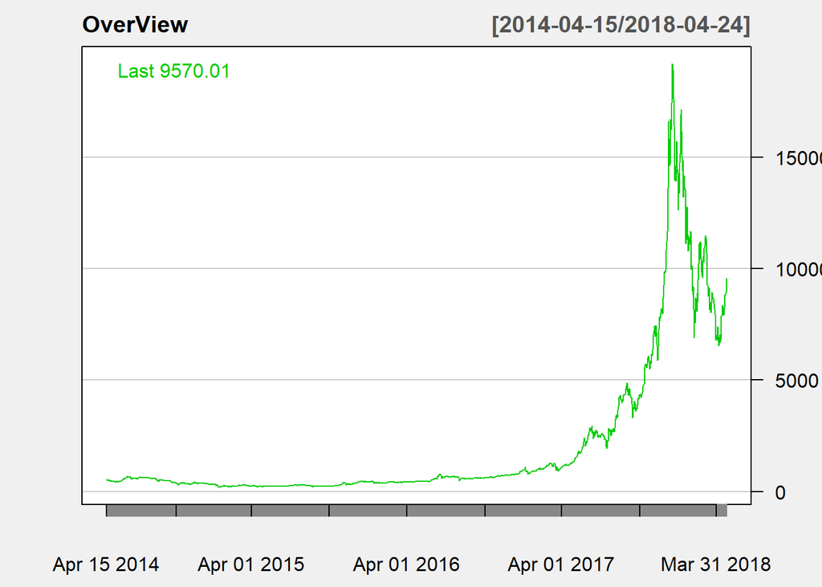

```r
Rawdata <- Quandl("BITSTAMP/USD")
LastPrice <- Rawdata$Last[length(Rawdata$Last):1]
OverView=xts(LastPrice,order.by=as.Date(Rawdata$Date[length(Rawdata$Last):1]))
ReturnRate <- dailyReturn(OverView,type="log")
chartSeries(OverView, theme = 'white')
```

## Graphical analysis

From the QQ Plot, we could know that the log return is not a normal distribtion. From the histogram, we could see that spillover and inverse leverage effect.

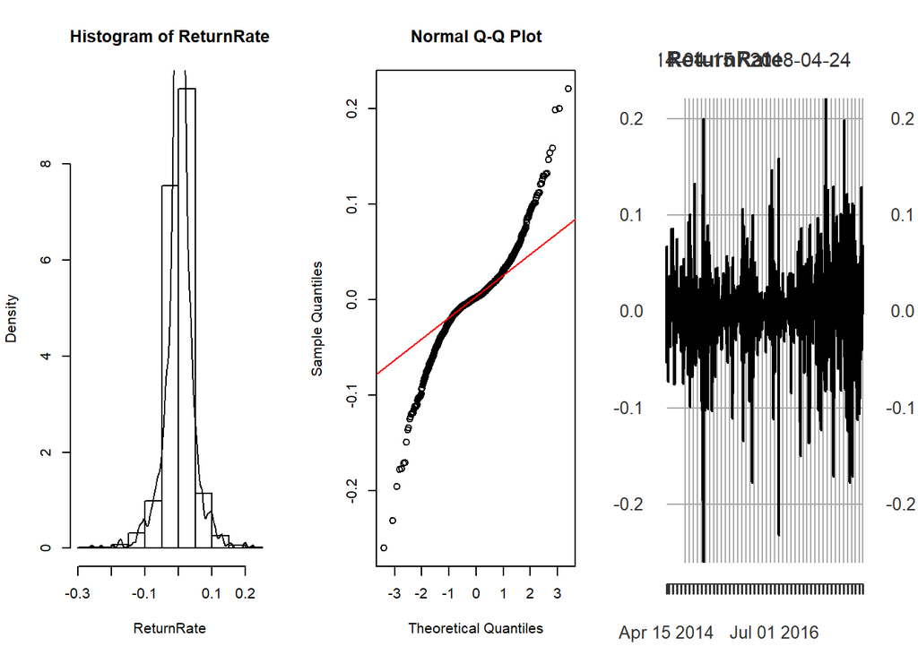

```r
par(mfcol=c(1,3))
hist(ReturnRate,prob = TRUE)
lines(density(ReturnRate))
qqnorm(ReturnRate); qqline(ReturnRate, col = 2)
plot(ReturnRate)
```

## Test distribtion

The kurtosis is 5.9, which obvious larger than 3. The distribution have heavy tails. The p-value of Jarque Bera test is less than 1%, reject H0, the distribution is not a normal distribution. SO, we should use “sted” for eGARCH.

```r
mean(ReturnRate)
```

```
## [1] 0.002035674
```

```r
skewness(ReturnRate, na.rm=T)
```

```
## [1] -0.3774989
## attr(,"method")
## [1] "moment"
```

```r
kurtosis(ReturnRate, na.rm=T)
```

```
## [1] 5.911522
## attr(,"method")
## [1] "excess"
```

```r
jarque.bera.test(ReturnRate)
```

```
##
##  Jarque Bera Test
##
## data:  ReturnRate
## X-squared = 2156.1, df = 2, p-value < 2.2e-16
```

## Test serial correlations

```r
adf.test(ReturnRate)
```

[output not shown]

## ARCH effects Test

From acf and pacf of ReturnRate^2, we could see the heteroscedasticity. And the p-value of Box-Ljung test is less than 0.01, serial has memory effect, after ARCH heteroscedasticity test for residuals, the p-value is less than 0.01, the residuals has ARCH effects.

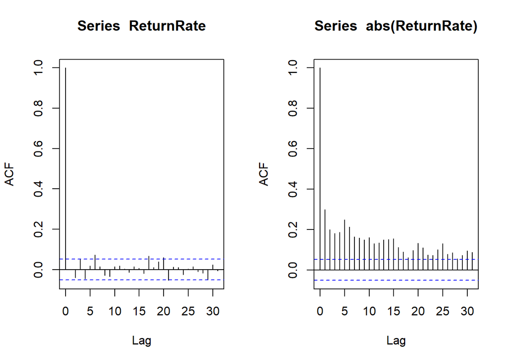

```r
par(mfcol=c(1,2))
acf(ReturnRate)
acf(abs(ReturnRate))
```

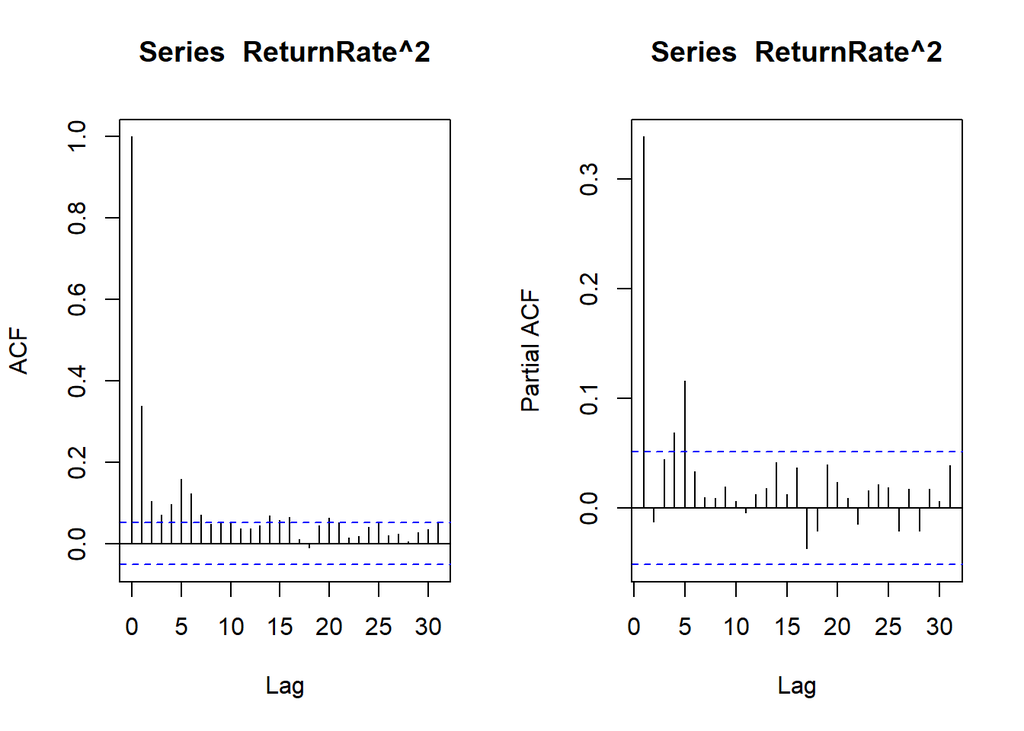

```r
acf(ReturnRate^2)
pacf(ReturnRate^2)
```

```r
Box.test (ReturnRate^2,lag=15, type = "Ljung")
```

```
##
##  Box-Ljung test
##
## data:  ReturnRate^2
## X-squared = 299.89, df = 15, p-value < 2.2e-16
```

```r
mod <- estimate(ReturnRate,p = 1)
```

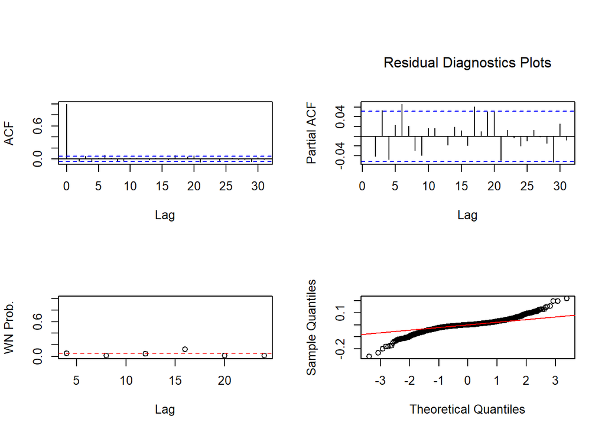

```
## ARIMA(1,0,0) model is estimated for variable: ReturnRate
##
## Conditional-Sum-of-Squares & Maximum Likelihood Estimation
##       Estimate     S.E t.value p.value Lag
## MU    0.002036 0.00105 1.94555  0.0519   1
## AR 1  0.000213 0.02627 0.00811  0.9935   1
## -----
## n = 1451; 'sigma' = 0.03983717; AIC = -5229.256; SBC = -5218.696
## ------------------------------
## Correlation of Parameter Estimates
##            MU   AR 1
## MU    1.00000 0.00112
## AR 1  0.00112 1.00000
## ------------------------------
## Autocorrelation Check of Residuals
##      lag    LB p.value
## [1,]   4  9.35  0.0530
## [2,]   8 19.04  0.0146
## [3,]  12 21.56  0.0428
## [4,]  16 22.66  0.1232
## [5,]  20 36.59  0.0131
## [6,]  24 41.97  0.0130
## ------------------------------
## Model for variable: ReturnRate
## Estimated mean: 0.002035765
## AR factors: 1 + 2e-04 B**(1)
```

```r
arch.test(mod)
```

```
## ARCH heteroscedasticity test for residuals
## alternative: heteroscedastic
##
## Portmanteau-Q test:
##      order  PQ p.value
## [1,]     4 204       0
## [2,]     8 273       0
## [3,]    12 285       0
## [4,]    16 306       0
## [5,]    20 315       0
## [6,]    24 321       0
## Lagrange-Multiplier test:
##      order   LM p.value
## [1,]     4 1123       0
## [2,]     8  510       0
## [3,]    12  337       0
## [4,]    16  248       0
## [5,]    20  193       0
## [6,]    24  159       0
```

[figure not shown]

## Find small AIC of ARMA model

```r
final.aic <- Inf
final.order <- c(0,0,0)
for (p in 0:5) for (q in 0:5){
  if ( p == 0 && q == 0){
    next
  }
  current.aic <- AIC(arima(ReturnRate,order=c(p,0,q)))
  if( current.aic < final.aic){
    final.aic <- current.aic
    final.order <- c(p, 0, q)
    final.arima <- arima(ReturnRate, order=final.order)
  } else {
    next
  }
}
final.order
```

```
## [1] 5 0 5
```

## Find suitable eGARCH model

GARCH Model: eGARCH(1,1)

Distribution: sged

```r
attspec = ugarchspec(
  variance.model=list(model="eGARCH",garchOrder=c(1,1)),
  mean.model=list(armaOrder=c(
    final.order[1], final.order[3]
  ), include.mean=T),
  distribution.model="sged"
)
attspec
```

```
##
## *---------------------------------*
## *       GARCH Model Spec          *
## *---------------------------------*
##
## Conditional Variance Dynamics
## ------------------------------------
## GARCH Model      : eGARCH(1,1)
## Variance Targeting   : FALSE
##
## Conditional Mean Dynamics
## ------------------------------------
## Mean Model       : ARFIMA(5,0,5)
## Include Mean     : TRUE
## GARCH-in-Mean        : FALSE
##
## Conditional Distribution
## ------------------------------------
## Distribution :  sged
## Includes Skew    :  TRUE
## Includes Shape   :  TRUE
## Includes Lambda  :  FALSE
```

```r
fit = tryCatch(
  ugarchfit(
    attspec, ReturnRate, solver = "hybrid"
  ), error=function(e) e, warning=function(w) w
)
fit
```

```
##
## *---------------------------------*
## *          GARCH Model Fit        *
## *---------------------------------*
##
## Conditional Variance Dynamics
## -----------------------------------
## GARCH Model  : eGARCH(1,1)
## Mean Model   : ARFIMA(5,0,5)
## Distribution : sged
##
## Optimal Parameters
## ------------------------------------
##         Estimate  Std. Error     t value Pr(>|t|)
## mu      0.001444    0.000067    21.50426  0.00000
## ar1     1.512000    0.007766   194.69937  0.00000
## ar2    -1.578712    0.007994  -197.49189  0.00000
## ar3     1.380090    0.006379   216.33430  0.00000
## ar4    -0.749416    0.004969  -150.82859  0.00000
## ar5     0.372235    0.004249    87.61475  0.00000
## ma1    -1.568718    0.000638 -2457.95422  0.00000
## ma2     1.642112    0.000684  2401.34766  0.00000
## ma3    -1.393126    0.001617  -861.43363  0.00000
## ma4     0.730125    0.002120   344.44614  0.00000
## ma5    -0.333411    0.002790  -119.52034  0.00000
## omega  -0.274460    0.019669   -13.95423  0.00000
## alpha1 -0.002217    0.011273    -0.19668  0.84408
## beta1   0.959604    0.003078   311.78402  0.00000
## gamma1  0.370818    0.032658    11.35454  0.00000
## skew    0.983132    0.008896   110.50902  0.00000
## shape   0.872299    0.039681    21.98295  0.00000
##
## Robust Standard Errors:
##         Estimate  Std. Error     t value Pr(>|t|)
## mu      0.001444    0.000035    41.55014  0.00000
## ar1     1.512000    0.006383   236.88798  0.00000
## ar2    -1.578712    0.005269  -299.61182  0.00000
## ar3     1.380090    0.004771   289.24578  0.00000
## ar4    -0.749416    0.003763  -199.16014  0.00000
## ar5     0.372235    0.002529   147.20313  0.00000
```

[output cut: 76 more lines]

```
## Negative Sign Bias  1.0127 0.3114
## Positive Sign Bias  1.3564 0.1752
## Joint Effect        3.3997 0.3340
##
##
## Adjusted Pearson Goodness-of-Fit Test:
## ------------------------------------
##   group statistic p-value(g-1)
## 1    20     28.71      0.07068
## 2    30     34.01      0.23888
## 3    40     42.56      0.32033
## 4    50     54.75      0.26541
##
##
## Elapsed time : 10.89633
```

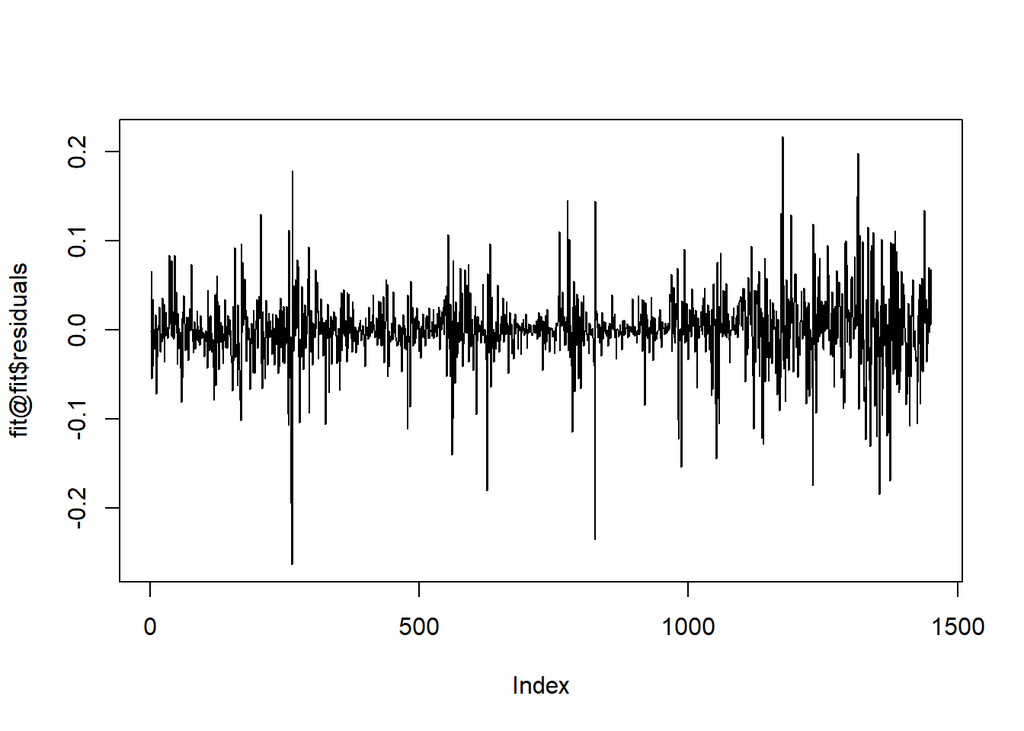

```r
plot(fit@fit$residuals,type="l")
```

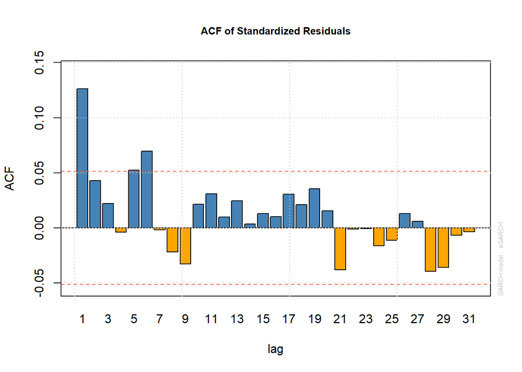

```r
plot(fit,which = 10)
```

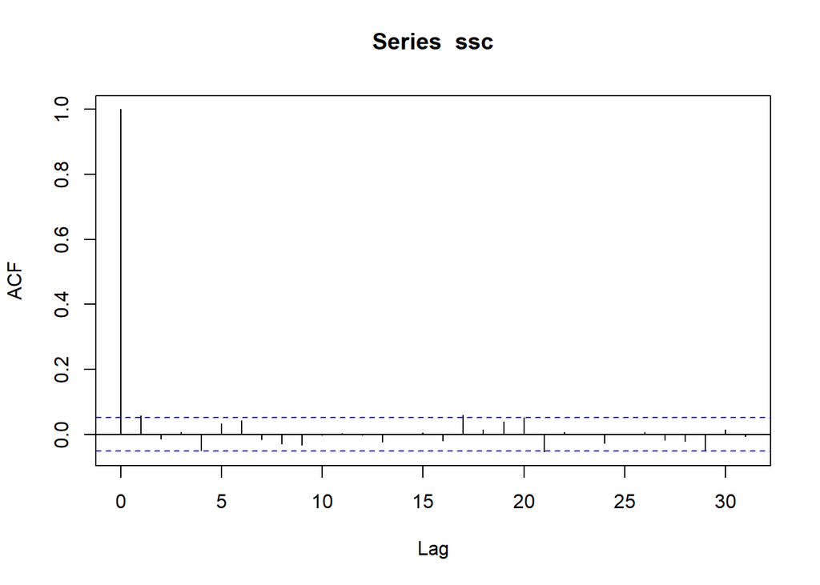

```r
ssc<-fit@fit$residuals
acf(ssc)
```

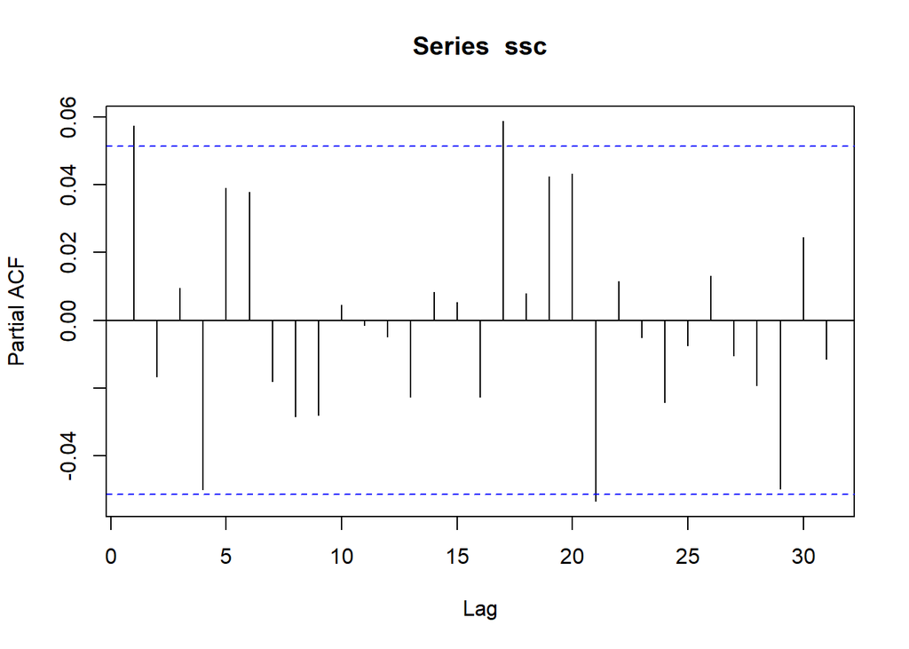

```r
pacf(ssc)
```

## Forecasting

```r
ugarch.roll<- ugarchroll(spec = attspec,
                         data= ReturnRate,
                         n.ahead = 1,
                         forecast.length =50,
                         refit.every = 20)
```

```r
show(ugarch.roll)
```

```
##
## *-------------------------------------*
## *              GARCH Roll             *
## *-------------------------------------*
## No.Refits        : 3
## Refit Horizon    : 20
## No.Forecasts : 50
## GARCH Model      : eGARCH(1,1)
## Distribution : sged
##
## Forecast Density:
##                Mu  Sigma   Skew  Shape Shape(GIG) Realized
## 2018-03-05 0.0014 0.0478 0.9849 0.8583          0   0.0037
## 2018-03-06 0.0059 0.0416 0.9849 0.8583          0  -0.0079
## 2018-03-07 0.0039 0.0386 0.9849 0.8583          0  -0.0602
## 2018-03-08 0.0041 0.0464 0.9849 0.8583          0  -0.0794
## 2018-03-09 0.0079 0.0568 0.9849 0.8583          0  -0.0634
## 2018-03-10 0.0066 0.0621 0.9849 0.8583          0  -0.0068
##
## ..........................
##                 Mu  Sigma   Skew  Shape Shape(GIG) Realized
## 2018-04-19  0.0019 0.0452 0.9761 0.8764          0   0.0110
## 2018-04-20 -0.0030 0.0408 0.9761 0.8764          0   0.0675
## 2018-04-21 -0.0025 0.0493 0.9761 0.8764          0  -0.0035
## 2018-04-22 -0.0002 0.0428 0.9761 0.8764          0   0.0065
## 2018-04-23  0.0012 0.0384 0.9761 0.8764          0   0.0085
## 2018-04-24 -0.0004 0.0348 0.9761 0.8764          0   0.0688
##
## Elapsed: 42.1043 secs
```

```r
report(ugarch.roll, type="fpm")
```

```
##
## GARCH Roll Mean Forecast Performance Measures
## ---------------------------------------------
## Model        : eGARCH
## No.Refits    : 3
## No.Forecasts: 50
##
##        Stats
## MSE 0.002181
## MAE 0.035460
## DAC 0.540000
```

## 50 days forecast

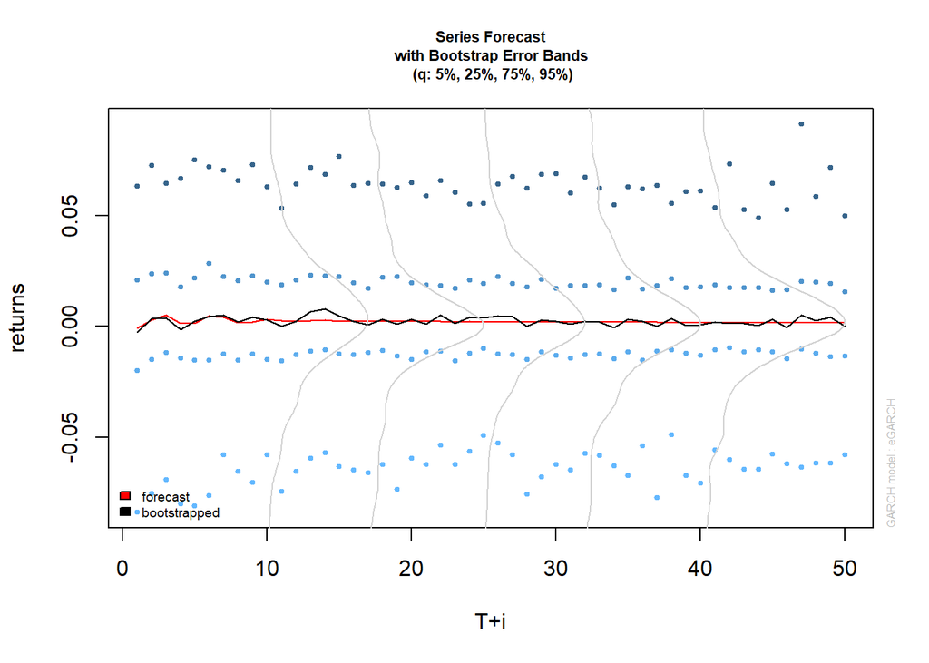

```r
fitpred<-ugarchboot(fit,n.ahead=50,method=c("Partial","Full")[1])
plot(fitpred,which=2)
```

## Dynamic forecast

```r
windowLength = 1400
foreLength = length(ReturnRate) - windowLength
forecasts <- vector(mode="character", length=foreLength)
t1<-Sys.time()
for (d in 0:foreLength) {
  spReturnsOffset = ReturnRate[(1+d):(windowLength+d)]
  final.aic <- Inf
  final.order <- c(0,0,0)
  for (p in 0:5) for (q in 0:5) {
    if ( p == 0 && q == 0) {
      next
    }
    arimaFit = tryCatch( arima(spReturnsOffset, order=c(p, 0, q)),
                         error=function( err ) FALSE,
                         warning=function( err ) FALSE )
    if( !is.logical( arimaFit ) ) {
      current.aic <- AIC(arimaFit)
      if (current.aic < final.aic) {
        final.aic <- current.aic
        final.order <- c(p, 0, q)
        final.arima <- arima(spReturnsOffset, order=final.order)
      }
    } else {
      next
    }
  }

  spec = ugarchspec(
    variance.model=list(model="eGARCH",garchOrder=c(1,1)),
    mean.model=list(armaOrder=c(
      final.order[1], final.order[3]
    ), include.mean=T),
    distribution.model="sged"
  )
  fit = tryCatch(
    ugarchfit(
      spec, spReturnsOffset, solver = "hybrid"
    ), error=function(e) e, warning=function(w) w
  )
  if(is(fit, "warning")) {
    forecasts[d+1] = paste(
      index(spReturnsOffset[windowLength]), 1, sep=","
    )
    print(
      paste(
        index(spReturnsOffset[windowLength]), 1, sep=","
      )
    )
  } else {
    fore = ugarchforecast(fit, n.ahead=1)
    ind = fore@forecast$seriesFor
    forecasts[d+1] = paste(
      colnames(ind), ifelse(ind[1] < 0, -1, 1), sep=","
    )
    print(paste(colnames(ind), ifelse(ind[1] < 0, -1, 1), sep=","))
  }
}
```

```
## [1] "2018-03-03,-1"
## [1] "2018-03-04,1"
## [1] "2018-03-05,1"
## [1] "2018-03-06,1"
## [1] "2018-03-07,1"
## [1] "2018-03-08,1"
## [1] "2018-03-09,1"
## [1] "2018-03-10,1"
## [1] "2018-03-11,1"
## [1] "2018-03-12,1"
## [1] "2018-03-13,-1"
## [1] "2018-03-14,1"
## [1] "2018-03-15,1"
## [1] "2018-03-16,-1"
## [1] "2018-03-17,1"
```

[output cut: 37 more lines]

```r
t2<-Sys.time()
print(t2-t1)
```

```
## Time difference of 12.71107 mins
```

```r
write.csv(forecasts, file="forecasts.csv", row.names=FALSE)

forecasts <- read.csv("forecasts.csv ",header = TRUE,sep = ",",quote
                      = "\"",stringsAsFactors=F)
forecasts  <- matrix(unlist(strsplit(forecasts$x,",")),ncol= 2, byrow = T)
head(forecasts)
```

```
##      [,1]         [,2]
## [1,] "2018-03-03" "-1"
## [2,] "2018-03-04" "1"
## [3,] "2018-03-05" "1"
## [4,] "2018-03-06" "1"
## [5,] "2018-03-07" "1"
## [6,] "2018-03-08" "1"
```

```r
class(forecasts)
```

```
## [1] "matrix"
```

```r
forecasts<-as.data.frame(forecasts)
names(forecasts)<-c("date","signal")
ssret<-xts(forecasts[,-1],order.by=as.Date(forecasts$date))
ssret<-xts(forecasts[,-1],order.by=as.Date(forecasts$date))
```

As, data is log return we could esaily add to calculate the final return.

```r
tradeRet<-ReturnRate*ssret
head(tradeRet)
```

```
##            daily.returns
## 2018-03-03  -0.010776425
## 2018-03-04   0.035638626
## 2018-03-05   0.003721516
## 2018-03-06  -0.007880940
## 2018-03-07  -0.060249053
## 2018-03-08  -0.079400681
```

```r
date<-index(tradeRet)
aa<-as.data.frame(tradeRet)
return<-aa[,1]
returns<-data.frame(date,return)
returns$signal<-returns$return >=0
head(returns)
```

```
##         date       return signal
## 1 2018-03-03 -0.010776425  FALSE
## 2 2018-03-04  0.035638626   TRUE
## 3 2018-03-05  0.003721516   TRUE
## 4 2018-03-06 -0.007880940  FALSE
## 5 2018-03-07 -0.060249053  FALSE
## 6 2018-03-08 -0.079400681  FALSE
```

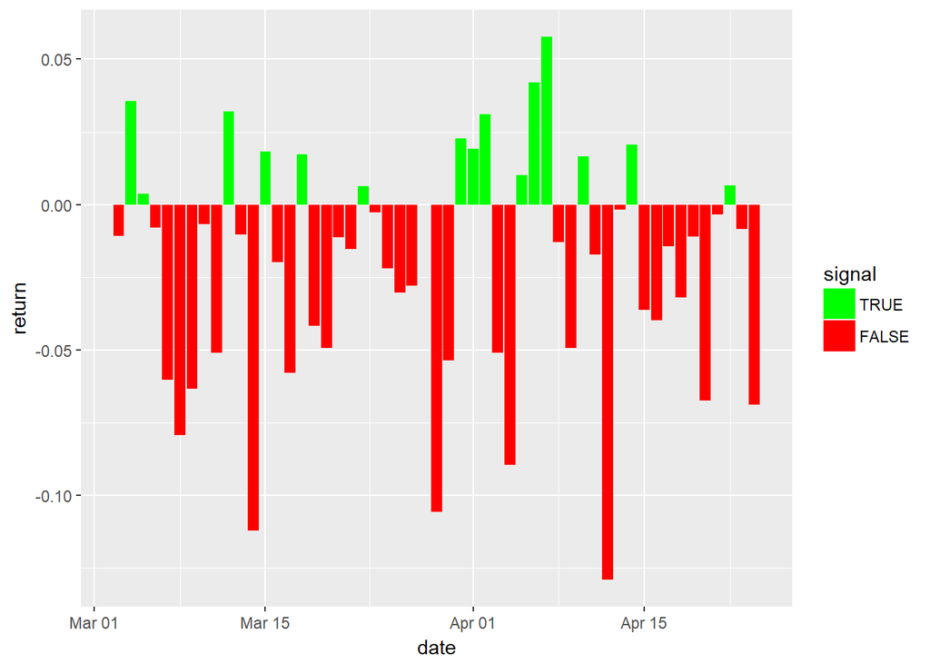

```r
ggplot(returns,aes(x=date,y=return,fill=signal))+
  geom_bar(stat="identity",position = "identity",size=0.1)+
  scale_fill_manual(values=c("red","green"))+
  guides(fill=guide_legend(reverse= TRUE))
```